# Decode the Bioreactor

Mechanistic, machine-learning and hybrid models of fed-batch CHO cultures

Author

SDSC STEM4Health hackathon, team 15

Published

November 22, 2026

> **Summary.** Neither a mechanistic model nor a machine-learning model alone predicts the cultures well. The mechanistic ODE gets the *shape* of a run right but misses batch-to-batch differences (CV MAPE 13.56). Machine learning on its own captures those differences but has no notion of dynamics or mass balance (8.18). Using the ODE as the backbone and learning only its *errors* combines their strengths (7.98, and down to 7.79 when the two families are averaged). The team’s best stack, hybrid v7, scored 6.752 on the leaderboard. Its last improvements came from stacking more and more models, and that has real costs in footprint, reproducibility and scientific clarity, which we discuss openly in Section 9. Our **final model, Option A**, keeps only what generalises, one sensor-assimilated mechanistic core with two learned corrections, and scored **6.81** (Section 10).

# 1 The problem

Each batch is one run of a fed-batch bioreactor: CHO cells grow on a substrate, produce a metabolic byproduct (and later partly consume it), and some of them die. Four feeds are dosed during the run, which raises the volume and dilutes every concentration. For each run we must predict four quantities on each of 13 days:

- **VCD**, the viable cell density;
- **TCD**, the total cell density (living and dead);
- **substrate** concentration;
- **byproduct** concentration.

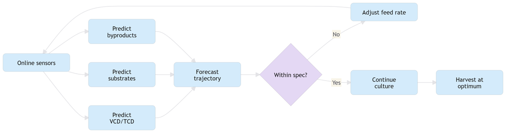

Why forecasting matters: a model of the culture lets the feeding be planned and the harvest timed.

**What is given.** 61 batches with 14 daily samples each. For 49 batches all measurements are known. For the 12 test batches only the **day-0 measurements** are given, together with the **complete feed schedule and volume log**. The task is therefore an *initial-value problem with known inputs*: from the state at day 0 and the planned feeds, forecast the whole run.

**How it is scored.** MAPE per variable, averaged over the four. MAPE weights small true values heavily (early cell counts, low byproduct) and punishes over-prediction without bound, so models are best fitted on a log or relative scale.

**One subtlety shapes everything that follows.** The feeding is *adaptive*: the main feed (Feed B) tracks the most recent cell count (r = 0.87). Operators dose according to what they measured. The feed log of a test batch therefore partly reveals how well it grew. A data-driven model can exploit this (legitimately: the test feeds are given), but the link runs “more cells → more feed”, not the other way round, so it is not process insight.

# 2 How we measured progress

All numbers in this report come from one reproducible pipeline (DVC), with every model scored the same way:

| Batches | Role |
| --- | --- |
| 39 *dev* batches | 5-fold cross-validation (CV). All model choices are made here. |
| 10 *holdout* batches | One final check per model, never used to choose. |
| 12 *test* batches | Scored by the organisers (leaderboard). |

Folds split whole batches, never days of the same batch. A validation batch is predicted exactly like a test batch: from its day-0 values and its feeds only. Anything learned from data (including pooled statistics such as the average feed schedule) is learned inside the training folds. Automated tests check that the holdout never influences fitting.

**Decision rule.** All models share the same 5 folds, so per-fold differences are far less noisy than the scores themselves. A change was adopted only if it lowered the CV MAPE on average **and** in at least 4 of the 5 folds. Rejected ideas are logged too (`docs/experiments.md`).

# 3 Baselines: how good is “the average run”?

Table 1: Baselines (CV MAPE, %).

| Name | Model | VCD | TCD | Substrate | Byproduct | Mean |
| --- | --- | --- | --- | --- | --- | --- |
| null_constant | Mean of each variable | 120.15 | 124.81 | 39.39 | 65.00 | 87.34 |
| null_per_day | Mean curve per culture day | 8.62 | 8.65 | 12.06 | 13.12 | 10.61 |

A constant is useless (87.34), but the **mean curve per culture day** is a strong baseline: 10.61. The runs follow a common recipe, so most of the variance is the shared time course. Every model below has to beat about 10.6.

# 4 The mechanistic approach

**Idea.** Write down the biology as ordinary differential equations: Monod-type growth on the substrate, a death rate, substrate uptake, byproduct production and consumption, and the dilution caused by each feed. Fit the kinetic parameters on the training batches, then simulate each new batch forward from its day-0 state and its own feed schedule.

Table 2: Pure mechanistic model vs. the per-day mean (CV MAPE, %).

| Name | Model | VCD | TCD | Substrate | Byproduct | Mean |
| --- | --- | --- | --- | --- | --- | --- |
| null_per_day | Mean curve per culture day | 8.62 | 8.65 | 12.06 | 13.12 | 10.61 |
| mechanistic_lite | Mass-balance ODE, no learned correction | 10.78 | 11.60 | 15.05 | 16.81 | 13.56 |

**Strengths.** The model is physically consistent by construction: concentrations stay positive, feeds enter as mass inputs, dilution is exact, and VCD stays below TCD. Its parameters mean something (a growth rate, a yield), and it can extrapolate to feeding strategies that were never run, which no purely statistical model can claim.

**Weaknesses.** On its own it is **worse than the per-day mean** (13.56 vs. 10.61). A handful of shared parameters cannot express how much batches differ from each other, the simplified metabolism misses effects such as the byproduct switch, and errors compound over 13 days of simulation. The figure shows the typical failure: the right shape, at the wrong level.

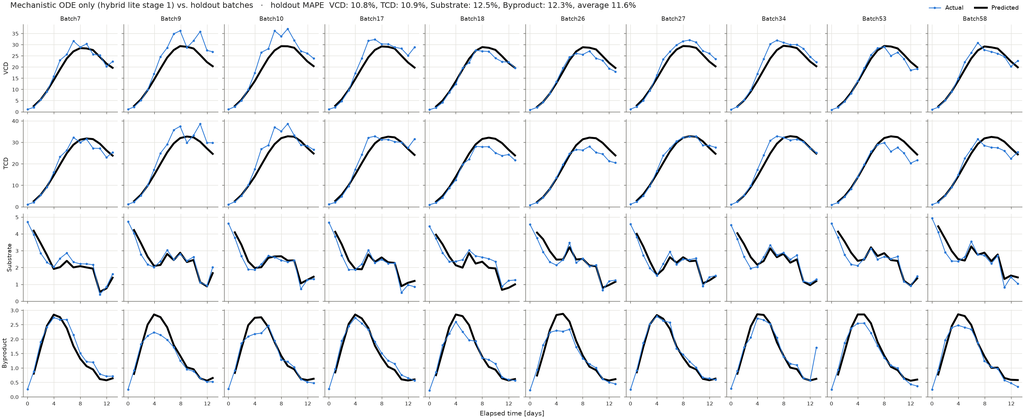

Pure mechanistic model on the holdout batches (predicted vs. measured).

# 5 The machine-learning approach

**Idea.** Treat each sample as a row of features (day, day-0 values, feeds so far, the feed dosed right after the sample) and learn the targets directly, with gradient boosting and ridge regression.

Table 3: The machine-learning ladder (CV MAPE, %).

| Name | Model | VCD | TCD | Substrate | Byproduct | Mean |
| --- | --- | --- | --- | --- | --- | --- |
| xgb_raw | XGBoost on raw features | 8.20 | 8.21 | 11.72 | 14.59 | 10.68 |
| xgb_log_fold_change | XGBoost on log fold change vs. day 0 | 7.93 | 7.75 | 11.52 | 13.80 | 10.25 |
| null_xgb_ensemble | Average of per-day mean and XGBoost | 7.82 | 7.80 | 11.24 | 13.42 | 10.07 |
| ml_sensors | Ridge + XGBoost with soft sensors | 7.39 | 7.32 | 9.39 | 8.63 | 8.18 |

- **The unlogged volume.** The volume minus the logged feeds, with the sampling losses added back. What remains reflects base addition, and therefore how acidic the culture became (a proxy for byproduct).
- **The substrate bolus.** The size of the late substrate top-ups, set by a controller that reacts to the measured substrate. It brackets the substrate level on those days.

With them, ML alone reaches 8.18.

**Strengths.** Flexible and fast (a fit takes about a second), and it reads batch-level signals from the feed logs, including the operators’ adaptive dosing.

**Weaknesses.** It knows nothing about dynamics or mass balance. With only 49 labelled batches it cannot learn the physics, so it leans on correlations, some of them reverse-causal (feeding follows growth). It cannot be trusted for a new feeding strategy, and it is weakest exactly where the mechanism is strongest: **substrate** (9.39 vs. 8.37 for the hybrid below).

# 6 The hybrid: the ODE as backbone, learning only its errors

**Idea.** Keep the mechanistic simulation as *stage 1*: it supplies a physically shaped trajectory for every batch. A *stage 2* learns only the correction, the log-ratio between the measurement and the stage-1 prediction, from the soft sensors and the batch’s inputs. Stage 2 blends two branches (a per-day ridge on the sensors and boosted trees) and, for the cell counts, a nearest-neighbour “similar batches” member.

1. **Stage 1:** the mechanistic ODE simulates the run from the day-0 state and the feed and volume log.
2. **Soft sensors** are computed from the same logs.
3. **Stage 2** learns the correction, log(measured / simulated), from the sensors and the day-0 state.
4. **Forecast** = simulation × correction.

Stage 2 is trained on stage-1 predictions for batches stage 1 had *not* seen (inner folds). The original team code skipped this, which made its CV slightly optimistic. Our version fixes it and learns all pooled statistics inside `fit`.

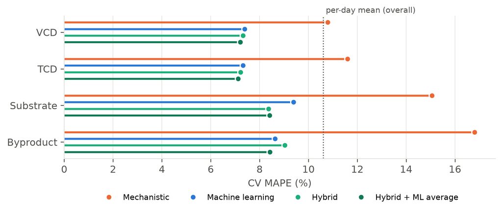

Figure 1: Per-variable CV MAPE of the three approaches. The hybrid inherits the mechanism’s strength on substrate and the data-driven model’s flexibility on the cell counts; on byproduct the data-driven model is still best, which is why averaging the two families helps again.

**Why the combination works.** The two families fail in different ways. The ODE’s errors are *systematic*: a whole batch running high or low, a byproduct switch at the wrong time. These are smooth, low-dimensional, and learnable from a few batch-level signals. Learning the correction is a much easier task than learning the whole trajectory. The data-driven stage never has to discover that cells grow, that feeds dilute, or that substrate is consumed: the ODE provides that for free. It only has to learn *how this batch differs*. That is why it works with 49 batches.

Table 4: Hybrid models (CV and holdout MAPE, %).

| Name | Model | VCD | TCD | Substrate | Byproduct | CV mean | Holdout |
| --- | --- | --- | --- | --- | --- | --- | --- |
| hybrid_v3 | Hybrid ODE (neural-net rates) + learned correction | 7.42 | 7.31 | 8.40 | 8.96 | 8.02 | 7.20 |
| hybrid_lite | Mechanistic ODE + learned correction | 7.32 | 7.22 | 8.37 | 9.04 | 7.98 | 6.88 |
| hybrid_blend | Average of hybrid_v3 and hybrid_lite | 7.33 | 7.23 | 8.27 | 8.97 | 7.95 | 6.99 |
| hybrid_blend_ml | Geometric average of hybrid_blend and ml_sensors | 7.20 | 7.12 | 8.41 | 8.42 | 7.79 | 6.84 |

One finding surprised us. A crude stage 1 (`hybrid_lite`: a plain ODE without neural nets, fitted in about a minute) is as good as an elaborate one (`hybrid_v3`: an ODE whose rates are corrected by neural networks, about 15 minutes per fit on 16 cores). Once stage 2 corrects the errors, the details of stage 1 matter little. Its *shape* matters.

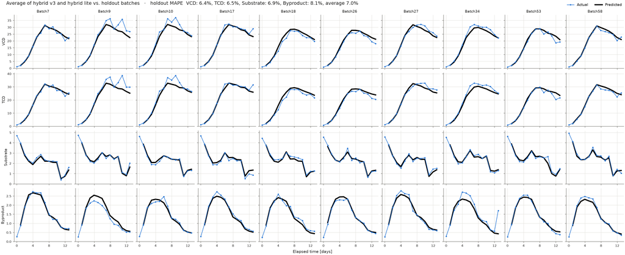

Hybrid model on the holdout batches.

# 7 Hybrid v7: the team’s best stack

Tobias’ hybrid v7 pushes the same idea further: four hybrids with different mechanistic cores, blended per variable and per phase of the run.

1. A **sensor-assimilated Monod core**: 400 per-batch parameter draws, weighted by how well each matches the substrate interval implied by the bolus controller and the unlogged volume. The sensors enter *the ODE itself* rather than only its correction. This was the largest single gain of the whole project.
2. A functional-PCA trajectory model on the same kind of core.
3. Hybrid v3.
4. A **two-population core**: growing cells switch to a non-growing, byproduct-consuming state.

Table 5: Version history of the team’s hybrid (Tobias’ 7-fold CV over all 49 labelled batches; not comparable with our 5-fold CV).

| Version | What | CV (7-fold) | Leaderboard |
| --- | --- | --- | --- |
| v3 | Hybrid ODE + soft sensors + learned correction | 7.674 | – |
| v5 | Stack of hybrids on several cores | 7.366 | 7.137 |
| v6 | 17-model stack, 10 more ideas | 7.244 | – |
| v7 | 4-model blend with sensor-assimilated cores | 7.187 | 6.752 |
| Option A | v7 cut to one core and two learned views (final) | 7.300 | 6.810 |

Table 6: Hybrid v7 blend weights per variable and phase of the run. Each variable relies on different cores, and the weights shift between the growth phase (days 1-6) and the late phase (days 7-13).

| Variable | Days | Assimilated Monod | Trajectory (fPCA) | Hybrid v3 | Two-population |
| --- | --- | --- | --- | --- | --- |
| VCD | days 1-6 | 0.00 | 0.24 | 0.76 | 0.00 |
| VCD | days 7-13 | 0.00 | 0.26 | 0.00 | 0.74 |
| TCD | days 1-6 | 0.00 | 0.27 | 0.73 | 0.00 |
| TCD | days 7-13 | 0.00 | 0.24 | 0.08 | 0.68 |
| Substrate | days 1-6 | 0.46 | 0.40 | 0.15 | 0.00 |
| Substrate | days 7-13 | 0.36 | 0.51 | 0.14 | 0.00 |
| Byproduct | days 1-6 | 0.00 | 0.08 | 0.92 | 0.00 |
| Byproduct | days 7-13 | 0.04 | 0.46 | 0.00 | 0.49 |

The weights tell the hybrid story in miniature. Substrate relies on the cores that know the feeding controller. In the growth phase the cell counts and byproduct rely on hybrid v3. Late in the run they shift to the two-population core, which models the transition the other cores miss.

# 8 Where the remaining error is

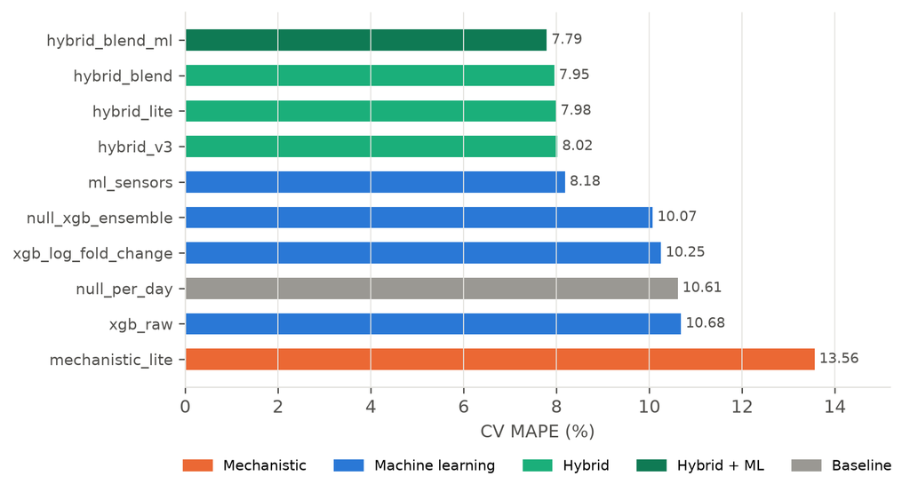

Figure 2: CV MAPE of every model in the pipeline, coloured by approach (5 dev folds, 39 batches).

# 9 The case against stacking more models

The last improvements on the leaderboard came largely from **combining models**: averaging hybrids, blending four cores with fitted weights, adding finishing models on top. It worked: 7.137 → 6.752 on the leaderboard. But it is worth being honest about what this practice costs.

**Footprint.** Every layer multiplies the cost of training and serving:

Table 7: Size of the fitted models (all 49 batches). Fit times are not shown: the hybrids’ stage-1 fits are cached, so the recorded times understate an uncached fit.

| Name | Model | Model size (MB) | CV MAPE |
| --- | --- | --- | --- |
| ml_sensors | Ridge + XGBoost with soft sensors | 1.93 | 8.18 |
| mechanistic_lite | Mass-balance ODE, no learned correction | 14.51 | 13.56 |
| hybrid_lite | Mechanistic ODE + learned correction | 14.51 | 7.98 |
| hybrid_v3 | Hybrid ODE (neural-net rates) + learned correction | 14.51 | 8.02 |
| hybrid_blend | Average of hybrid_v3 and hybrid_lite | 29.02 | 7.95 |
| hybrid_blend_ml | Geometric average of hybrid_blend and ml_sensors | 30.95 | 7.79 |

- An uncached `hybrid_v3` fit takes six stage-1 fits of about 15 minutes each on 16 cores (one on all training batches, five inner folds for the stacking). A blend fits all of its members.
- Hybrid v7 needs four mechanistic cores (one with 400 particles per batch), about 2,000 lines of code in ten scripts, and a chain of cached intermediate files. Rerunning its pinned commit reproduces its CV exactly, but not the submitted file: most predictions agree within 0.2%, one differs by 20%, because an intermediate cache changed between submission and commit. The more layers, the more places for this to happen.
- For deployment on a controller or a soft-sensor device, a 2 MB ridge + boosting model and a 30 MB, multi-stage, multi-core blend are different engineering propositions.

**Diminishing and noisy returns.** Averaging `hybrid_v3` and `hybrid_lite` gained 0.05 CV MAPE, because their predictions differ by only 1.4%. Averaging two near-copies adds little. Averaging two genuinely different families (`hybrid_blend_ml`) gained more (0.16) but improved only 3 of 5 folds, failing our own rule. Tobias’ v6 stack of 17 models scored *worse* than the 4-model v7. The leaderboard has only 12 batches. When two candidates differ by 1-2% per prediction, a ±0.3 change in score is noise, and we saw both directions.

**It is unprincipled.** Each extra layer is chosen because it lowered a score, on the same folds that report the score. Blend weights per variable and per phase, the choice among candidate sets, the finishing steps: every choice spends a little of the validation set’s honesty. Tobias estimates about 0.03 MAPE of optimism from choosing among six 4-model sets alone. More importantly, a stack does not explain anything. We cannot read a growth rate or a yield from a geometric blend of four corrected simulators. Without the forecast accuracy, the model gives no answer to *why* a batch behaves as it does, and that was half of the challenge’s brief.

**What we would keep.** The gains that came from **ideas** rather than **layers** are the ones that generalise: soft sensors that turn the feed and volume logs into indirect measurements, assimilating them *into* the ODE, and the hybrid structure itself. A defensible final model is one mechanistic core with sensor assimilation plus a learned correction. It is small enough to audit, fit and deploy, and within a few tenths of the best stack. That is the model we adopted.

# 10 Option A: the final model

Option A is v7 cut down to that recipe. It keeps v7’s **sensor-assimilated Monod core** and puts two learned views on it: the hybrid v3 correction and the functional-PCA trajectory model. Their predictions are blended geometrically, with weights per variable and per phase fitted on out-of-fold predictions. The finishing steps are v7’s: glucose goes to the most likely point inside the interval implied by the bolus controller, and TCD ≥ VCD. Three of v7’s four cores and its TCD ratio model are gone.

Table 8: Option A and hybrid v7 (MAPE, %). The 7-fold CV and the leaderboard are Tobias’ protocol. The holdout row is Option A’s out-of-fold prediction of our 10 holdout batches; it is not the same protocol as our holdout check (see text).

|  | VCD | TCD | Substrate | Byproduct | Mean |
| --- | --- | --- | --- | --- | --- |
| Option A: 7-fold CV | 6.90 | 6.82 | 7.24 | 8.25 | 7.30 |
| Hybrid v7: 7-fold CV | 6.77 | 6.71 | 7.17 | 8.10 | 7.19 |
| Option A: leaderboard | 6.57 | 6.41 | 6.55 | 7.72 | 6.81 |
| Hybrid v7: leaderboard | 6.61 | 6.46 | 6.48 | 7.46 | 6.75 |
| Option A: our holdout (out-of-fold) | 6.18 | 6.17 | 6.59 | 7.53 | 6.62 |

Option A is 0.06 worse than v7 on the leaderboard and 0.11 worse in CV, with one core instead of four. Its code, ported to this repository, reproduces the submitted file exactly (largest difference 2e-12%), where v7’s rerun differs by up to 20%. It was chosen by the team for this simplicity, not by our per-fold rule: it has no CV on our 5 dev folds.

Table 9: Option A blend weights per variable and phase of the run.

| Variable | Days | Hybrid v3 correction | Trajectory (fPCA) |
| --- | --- | --- | --- |
| VCD | days 1-6 | 0.74 | 0.26 |
| VCD | days 7-13 | 0.76 | 0.24 |
| TCD | days 1-6 | 0.76 | 0.24 |
| TCD | days 7-13 | 0.76 | 0.24 |
| Substrate | days 1-6 | 0.62 | 0.38 |
| Substrate | days 7-13 | 0.50 | 0.50 |
| Byproduct | days 1-6 | 0.98 | 0.02 |
| Byproduct | days 7-13 | 0.60 | 0.40 |

The hybrid v3 correction carries most of the weight. The trajectory model matters most for substrate (half of the late phase) and for late byproduct. Option A has no model fitted on our 39 dev batches, so it cannot be scored exactly like the models above. Its out-of-fold predictions of our holdout batches come from models that never saw those batches, but were fitted on about 42 of the 49 labelled batches, the other holdout batches included. They score 6.62, against 6.84 for our best in-house model on its stricter protocol.

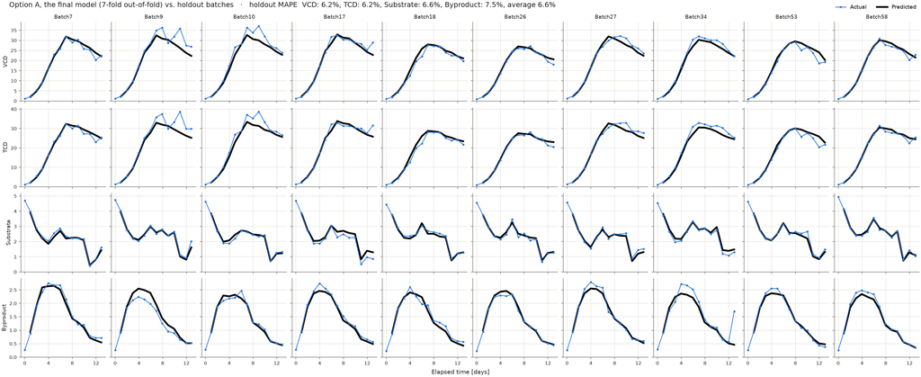

Option A on our holdout batches (out-of-fold predictions from its own 7-fold CV).

# 11 Screening for abnormal batches

A forecast model also defines what *normal* looks like. Triantafyllia’s anomaly analysis (`notebooks/anomaly_v7.ipynb`) uses the out-of-fold residuals, log(measured / predicted), of the final model, Option A, on the 49 labelled batches as the normal behaviour, without any rejected batch or label. Each batch is compared with the other 48. A **batch score** (robust z-values and a PCA of the residual patterns) catches diffuse deviations, and **cell-level rules** catch one-day spikes and deviations that persist for three days or more.

Table 10: Deviations flagged in the labelled batches at the standard level (z-values against the other 48 batches).

| batch | type | variable | days | mean z | measured vs predicted (%) | strict level |
| --- | --- | --- | --- | --- | --- | --- |
| Batch46 | persistent | Substrate | 5-7 | -6.0 | -31 | yes |
| Batch42 | persistent | Substrate | 6-10 | 3.7 | 29 | no |
| Batch50 | persistent | Substrate | 4-6 | 3.2 | 23 | no |
| Batch34 | spike | Byproduct | 13 | 7.9 | 269 | yes |
| Batch29 | spike | Byproduct | 13 | 7.5 | 242 | yes |
| Batch3 | spike | VCD | 8 | 5.6 | 29 | no |

The batch score flags 6 of 49 batches, the cell rules 6 (strict level: 3). The two byproduct values on day 13 jump about threefold within a day, which suggests a measurement or sampling problem rather than metabolism. These are candidates for a process expert, not confirmed anomalies: the flagged share matches the false-alarm rate the thresholds were set to. The same analysis on hybrid v7’s residuals (stage `anomaly@hybrid_v7`) flags 5 batches at the cell level, of which 4 are also flagged here: the clear cases do not depend on the model, the borderline ones do.

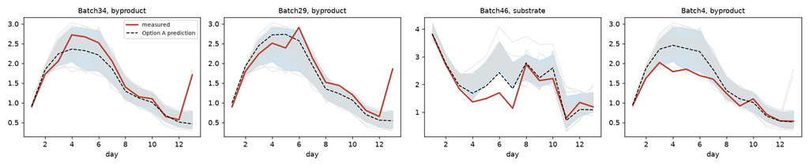

Flagged examples: measured (red) and Option A prediction (dashed), against all labelled batches (grey, 5-95% band in blue).

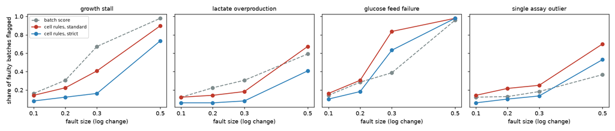

Share of faulty batches flagged, by fault type and size.

# 12 Reproducibility

- **One pipeline.** `dvc repro` rebuilds every number and figure in this report from the raw data, the frozen split, the code and `params.yaml`. DVC reruns only what changed.
- **Versioned models.** Model versions are git tags in a registry (GTO), not “_v2” file names. Each tag points at the commit whose code, parameters and lock file produced it. Option A, the final model, is registered in stage `prod`; its code is ported unchanged from its branch. Hybrid v7 runs from a pinned commit of its own branch.
- **One dependency outside this branch.** Option A reads cached intermediate outputs, and hybrid v7 runs code, from branch `hybrid_v3_tr`, which therefore has to stay available. Their results are committed here, but rerunning them needs that branch; the other models need only the raw data.
- **Logged decisions.** Every experiment, including the rejected ones, is recorded with its per-fold result in `docs/experiments.md`.
- **No data in git.** Only hashes of the challenge data, and no file in `reports/` contains measured values.

# 13 Limitations and next steps

- Our CV (5 folds, 39 batches) and Tobias’ (7 folds, 49 batches) are different protocols. Option A and hybrid v7 are compared with our models on the leaderboard, and Option A also through its out-of-fold predictions of our holdout batches, which are not quite our holdout protocol.
- Data-driven parts exploit the adaptive feeding, which helps the forecast but would break under a new feeding strategy. A deployment for process design should restrict stage 2 to causal inputs, or at least test it on feeding schedules outside the historical range.
- Next steps, in order of expected value: a single sensor-assimilated core with a learned correction as the reference model; interpretable reporting of the fitted kinetic parameters per batch; and asking for online sensor data (pH, dissolved oxygen, base addition), which would attack the per-batch offsets directly.